# 基本面分析与技术分析如何结合？

#### *狗熊会*

案例难度：***

案例背景：2019年年末，新冠疫情的冲击为全球市场带来了几乎前所未有的动荡，中国市场也难逃其影响。但随着中国国内的疫情防控到位，国内生产总值逐渐恢复增长——2020年我国的国内生产总值达到了101.6万亿元，比上年增长2.3%。随着国内生产总值的增长，居民的人均可支配收入及储蓄总量也随之增长，从而家庭的财富总量也随之增长。因此，让家庭的财富能够更好的保值增值逐渐成为居民关心的重点之一。家庭财富实现保值增值的最常见方式即为投资，而投资方式中的金融投资始终都占据着“半壁江山”以上。并且在金融投资中，相比银行储蓄存款，证券（股票、债券等）更能够满足人们对家庭财富保值增值的期望。因此近年来，在金融投资中证券的占比逐渐增长且趋于稳定——其中证券中的股票，相比债券，收益更高、风险更大，更需要人们运用金融知识及分析方法去谨慎投资来获取高额收益。

本案例所使用的数据来自东方财富choice金融终端的股票数据，包括因变量yield(stock中为五天收益率，df_jiben中为季度收益率）、技术面指标MACD（macd）、KDJ（kdj）、RSI（rsi）、WR（wr）,基本面指标每股收益、每股净资产、净资产收益率、资产负债率、流动比率、总资产周转率。

这个案例的学习目标包括：

1.了解股票相关的数据；

2.学会对数据做基本的描述性分析，并且适当解读；

3.建立线性回归模型，使用AIC准则进行变量筛选，构建股票组合；

4.建立随机森林模型，构建股票组合，并分析变量重要性。

## 准备工作

```r
# 清除工作环境
rm(list=ls())
# 需设置工作路径
# setwd()

# 加载所需的R包
library(ggplot2) # 可视化
library(moments) # 偏度与峰度计算
library(dplyr) # 处理数据
library(randomForest) # 建立随机森林模型
```

## 任务一

找到数据stock与df_jiben，读入样本数据，分布命名为stock与df_jiben，并使用summary函数查看数据中变量的信息。

```r
# 读取文件
stock=read.csv("E:/data/stock.csv")
df_jiben=read.csv("E:/data/df_jiben.csv")
# 查看股票数据记录的变量情况
summary(stock)
```

```
##         代码            名称              时间.x           macd
##  000001.SZ:   24   *ST艾格:   24   2018/12/24: 3518   Min.   :-5.0000
##  000002.SZ:   24   *ST巴士:   24   2018/12/17: 3517   1st Qu.:-3.0000
##  000004.SZ:   24   *ST百花:   24   2018/12/10: 3516   Median : 0.0000
##  000005.SZ:   24   *ST邦讯:   24   2018/12/3 : 3515   Mean   :-0.8382
##  000006.SZ:   24   *ST宝德:   24   2018/11/19: 3511   3rd Qu.: 0.0000
##  000007.SZ:   24   *ST博信:   24   2018/11/26: 3511   Max.   : 5.0000
##  (Other)  :83829   (Other):83829   (Other)   :62885
##       kdj               rsi                 wr              yield
##  Min.   :-5.0000   Min.   :-5.00000   Min.   :-5.0000   Min.   :-41.0569
##  1st Qu.: 0.0000   1st Qu.: 0.00000   1st Qu.:-2.0000   1st Qu.: -3.9697
##  Median : 0.0000   Median : 0.00000   Median : 1.0000   Median : -0.3807
##  Mean   : 0.1692   Mean   : 0.00805   Mean   : 0.4315   Mean   : -0.4705
##  3rd Qu.: 0.0000   3rd Qu.: 0.00000   3rd Qu.: 3.0000   3rd Qu.:  2.8497
##  Max.   : 5.0000   Max.   : 5.00000   Max.   : 5.0000   Max.   : 61.4987
##
##     每股收益         每股净资产      净资产收益率         资产负债率
##  Min.   :-7.8900   Min.   :-2.600   Min.   :-1280.000   Min.   :  0.926
##  1st Qu.: 0.0600   1st Qu.: 2.790   1st Qu.:    1.930   1st Qu.: 25.100
##  Median : 0.1780   Median : 4.140   Median :    4.440   Median : 40.700
##  Mean   : 0.2735   Mean   : 4.771   Mean   :    4.237   Mean   : 42.190
##  3rd Qu.: 0.3790   3rd Qu.: 5.920   3rd Qu.:    7.710   3rd Qu.: 56.800
##  Max.   :19.7000   Max.   :81.500   Max.   :   86.800   Max.   :180.000
##
##     流动比率       总资产周转率
##  Min.   : 0.000   Min.   :-0.000666
##  1st Qu.: 1.180   1st Qu.: 0.183000
##  Median : 1.690   Median : 0.307000
##  Mean   : 2.486   Mean   : 0.380725
##  3rd Qu.: 2.730   3rd Qu.: 0.474000
##  Max.   :66.500   Max.   : 6.710000
##
```

```r
summary(df_jiben)
```

```
##         代码            名称               时间          每股收益
##  000027.SZ:   14   *ST飞马:   14   2021/3/31 : 4214   Min.   :-24.8000
##  000156.SZ:   14   *ST香梨:   14   2020/12/31: 4123   1st Qu.:  0.0300
##  000498.SZ:   14   *ST永林:   14   2020/9/30 : 4015   Median :  0.1320
##  000563.SZ:   14   *ST云城:   14   2020/6/30 : 3843   Mean   :  0.2564
##  000663.SZ:   14   ST龙韵 :   14   2020/3/31 : 3772   3rd Qu.:  0.3500
##  000683.SZ:   14   ST仁智 :   14   2019/12/31: 3726   Max.   : 37.2000
##  (Other)  :48659   (Other):48659   (Other)   :25050
##    每股净资产       净资产收益率          资产负债率          流动比率
##  Min.   :-15.400   Min.   :-15800.000   Min.   :    0.00   Min.   :  0.000
##  1st Qu.:  2.790   1st Qu.:     0.903   1st Qu.:   25.30   1st Qu.:  1.150
##  Median :  4.290   Median :     3.180   Median :   41.10   Median :  1.680
##  Mean   :  5.179   Mean   :     2.478   Mean   :   44.03   Mean   :  2.603
##  3rd Qu.:  6.420   3rd Qu.:     7.170   3rd Qu.:   57.65   3rd Qu.:  2.810
##  Max.   :140.000   Max.   :  1100.000   Max.   :19200.00   Max.   :115.000
##
##   总资产周转率         yield
##  Min.   :-0.1380   Min.   :-82.800
##  1st Qu.: 0.1180   1st Qu.:-12.300
##  Median : 0.2470   Median : -2.230
##  Mean   : 0.3517   Mean   :  1.817
##  3rd Qu.: 0.4660   3rd Qu.: 10.800
##  Max.   :12.0000   Max.   :199.202
##
```

## 任务二

使用ggplot函数绘制因变量：绘制收益率的直方图，查看因变量的分布形态，并用skeweness和kurtosis查看收益率的偏度和峰度，做初步分析。  
提示：  
1.首先需要将因变量数值化，再进行画图。

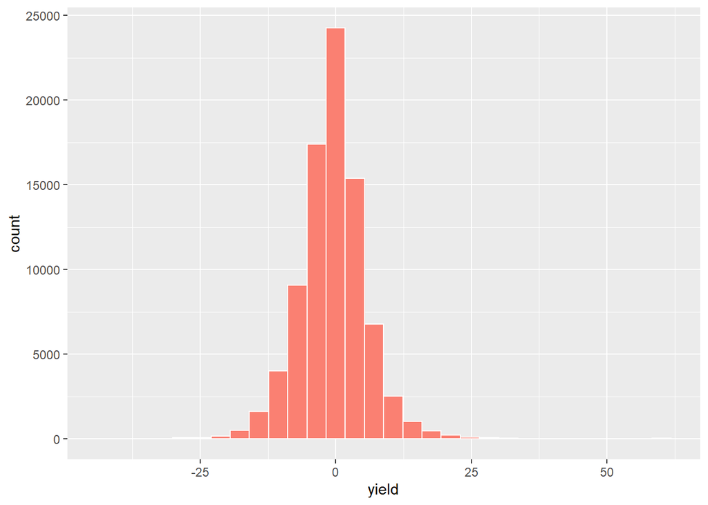

```r
# 用as.numeric函数将五天交易日的yield变量的数据转换为数值型
stock$yield<- as.numeric(stock$yield)
# 用as.Date函数将时间变量转换为日期型数据
stock$时间=as.Date(stock$时间)
# 将以时间进行排序
stock=stock[order(stock$时间),]

# 用as.numeric函数将季度的yield变量的数据转换为数值型
df_jiben$yield<- as.numeric(df_jiben$yield)
# 用as.Date函数将时间变量转换为日期型数据
df_jiben$时间=as.Date(df_jiben$时间)
# 将data以时间变量进行排序
df_jiben=df_jiben[order(df_jiben$时间),]

# 用ggplot函数绘制五天收益率直方图
ggplot(stock, aes(x = yield))+geom_histogram(stat = "bin",bins=30,fill = "salmon", colour = "white")
```

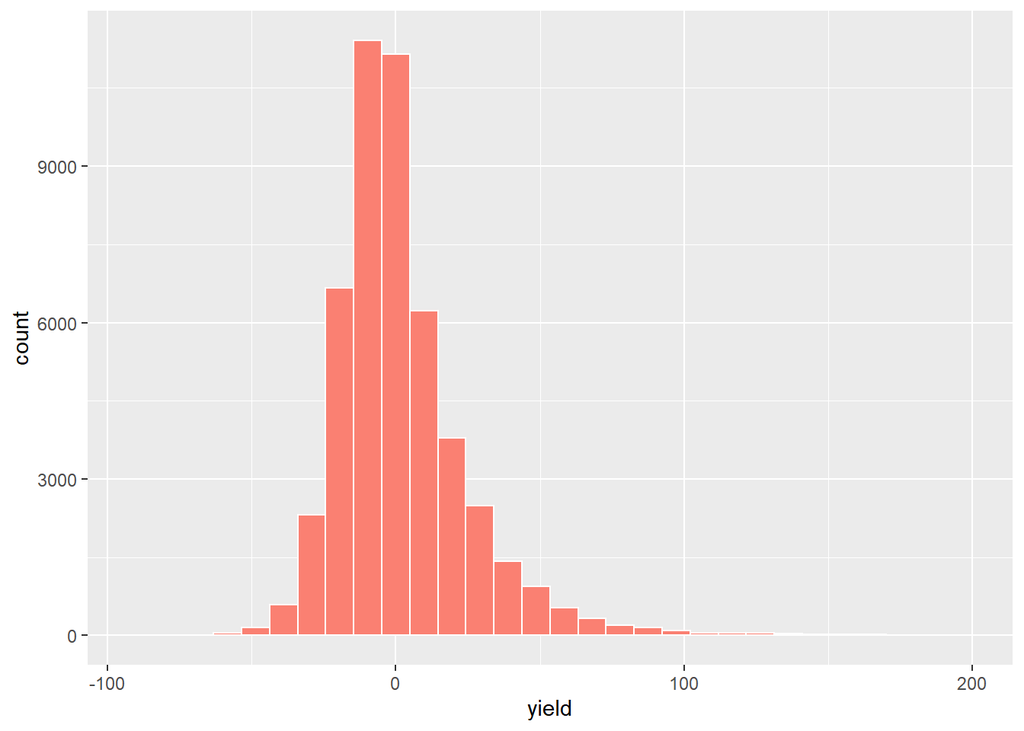

```r
# 用ggplot函数绘制季度收益率直方图
ggplot(df_jiben, aes(x = yield))+geom_histogram(stat = "bin",bins=30,fill = "salmon", colour = "white")
```

```r
# 计算收益率的偏度和峰度
fenbu1=c(skewness(stock$yield),kurtosis(stock$yield))
fenbu1
```

```
## [1]  0.8276032 11.4161331
```

```r
fenbu2=c(skewness(df_jiben$yield),kurtosis(df_jiben$yield))
fenbu2
```

```
## [1]  1.817403 10.143486
```

解读：从直方图和偏度、峰度可以知道股票五天收益率与季度收益率都呈现右偏以及明显的尖峰厚尾状态，这说明大部分股票的收益率在0上下波动，且有不低的概率会小于0。因此我们研究基本面分析与技术分析如何结合能更有效选股，对想进行股票投资的人们是有实践意义的。

## 任务三

使用ggplot函数绘制基本面指标—每股收益的选股效果：绘制分组箱线图，研究每股收益对季度收益率的影响。

提示：  
1.首先需要把基本面指标-每股收益按高和低进行划分，为对比明显，选取排名前20的股票为高，排名后20的股票为低。  
2.当使用原始数据绘制的箱线图过于扁平时（即数据差异过大），可绘制对数变换后的分组箱线图。

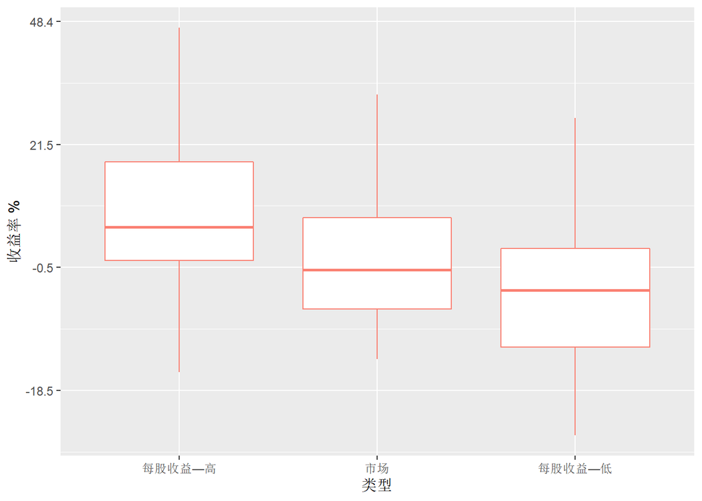

```r
# 选取每股收益排名前20的股票作为每股收益—高的组合，以及选取每股收益排名后20的股票作为每股收益—低的组合
data1=df_jiben %>%
  group_by(时间) %>%
  arrange(每股收益)%>%
  mutate(lowmeans=mean(yield[1:20]),highmeans=mean(yield[(length(yield)-19):length(yield)]),market=mean(yield))
#提取出每一季度的三类组合的收益率
data1.1=unique(data1[,11:13])

#为每股收益三类组合的收益率分布打上类型的标签
output1=data.frame(收益率=c(data1.1$lowmeans,data1.1$market,data1.1$highmeans),类型=c(rep("每股收益—低",14),rep("市场",14),rep("每股收益—高",14)))
#固定箱线图的排序
output1$类型=factor(output1$类型,levels=c("每股收益—高","市场","每股收益—低"))
# 用ggplot函数绘制每股收益的分组箱线图
p1=ggplot(data=output1,aes(x=类型,y=log(100+收益率)))+geom_boxplot(colour="salmon")+scale_fill_hue(c=45,l=80)+labs(y="收益率 %")+scale_y_continuous(breaks=c(4.4,4.6,4.8,5.0),labels=c("-18.5","-0.5","21.5","48.4"))
p1
```

解读：可以看出选出的每股收益高的股票组合相比市场显著中位数更高，整体收益率更优；而每股收益低的股票组合相比市场显著中位数更低，整体收益率更差。这说明上季度价值指标高的股票组合，相比价值指标低的股票组合以及市场，在这季度的收益率大概率会表现更好。

## 任务四

使用ggplot函数绘制基本面指标—净资产收益率的选股效果：绘制分组箱线图，研究净资产收益率对季度收益率的影响。

提示：  
1.首先需要把基本面指标-净资产收益率按高和低进行划分，为对比明显，选取排名前20的股票为高，排名后20的股票为低。  
2.当使用原始数据绘制的箱线图过于扁平时（即数据差异过大），可绘制对数变换后的分组箱线图。

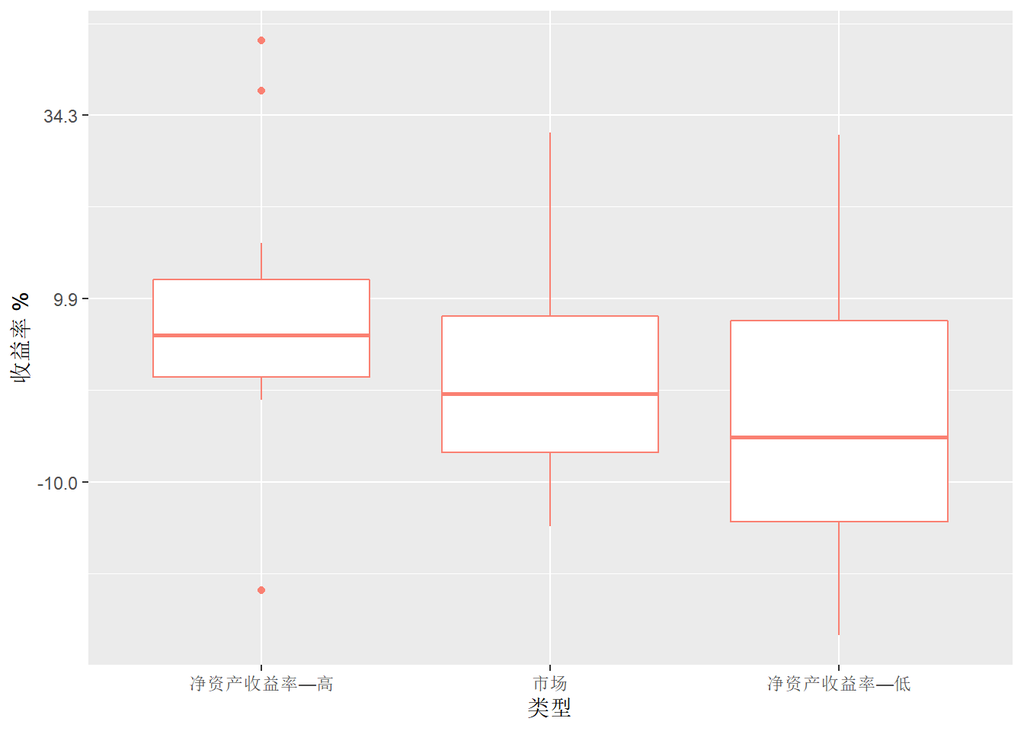

```r
#选取净资产收益率排名前20的股票作为净资产收益率—高的组合，以及选取净资产收益率排名后20的股票作为净资产收益率—低的组合
data2=df_jiben %>%
  group_by(时间) %>%
  arrange(净资产收益率)%>%
  mutate(lowmeans=mean(yield[1:20]),highmeans=mean(yield[(length(yield)-19):length(yield)]),market=mean(yield))
#提取出每一季度的三类组合的收益率
data2.1=unique(data2[,11:13])

#为净资产收益率三类组合的收益率分布打上类型的标签
output2=data.frame(收益率=c(data2.1$lowmeans,data2.1$market,data2.1$highmeans),类型=c(rep("净资产收益率—低",14),rep("市场",14),rep("净资产收益率—高",14)))
#固定箱线图的排序
output2$类型=factor(output2$类型, levels=c("净资产收益率—高","市场","净资产收益率—低"))
# 用ggplot函数绘制净资产收益率的分组箱线图
p2=ggplot(data=output2,aes(x=类型,y=log(100+收益率)))+geom_boxplot(colour="salmon")+scale_fill_hue(c=45, l=80)+labs(y="收益率 %")+scale_y_continuous(breaks = c(4.5,4.7,4.9),labels = c("-10.0","9.9","34.3"))
p2
```

解读：可以看出选出的净资产收益率高的股票组合相比市场显著中位数更高，整体收益率更优；而净资产收益率低的股票组合相比市场显著中位数更低，整体收益率更差。这说明上季度盈利能力指标高的股票组合，相比盈利能力指标低的股票组合以及市场，同样在这季度的收益率大概率会表现更好。

## 任务五

使用ggplot函数绘制基本面指标—资产负债率的选股效果：绘制分组箱线图，研究资产负债率对季度收益率的影响。

提示：  
1.首先需要把基本面指标-资产负债率按高和低进行划分，为对比明显，选取排名前20的股票为高，排名后20的股票为低。  
2.当使用原始数据绘制的箱线图过于扁平时（即数据差异过大），可绘制对数变换后的分组箱线图。

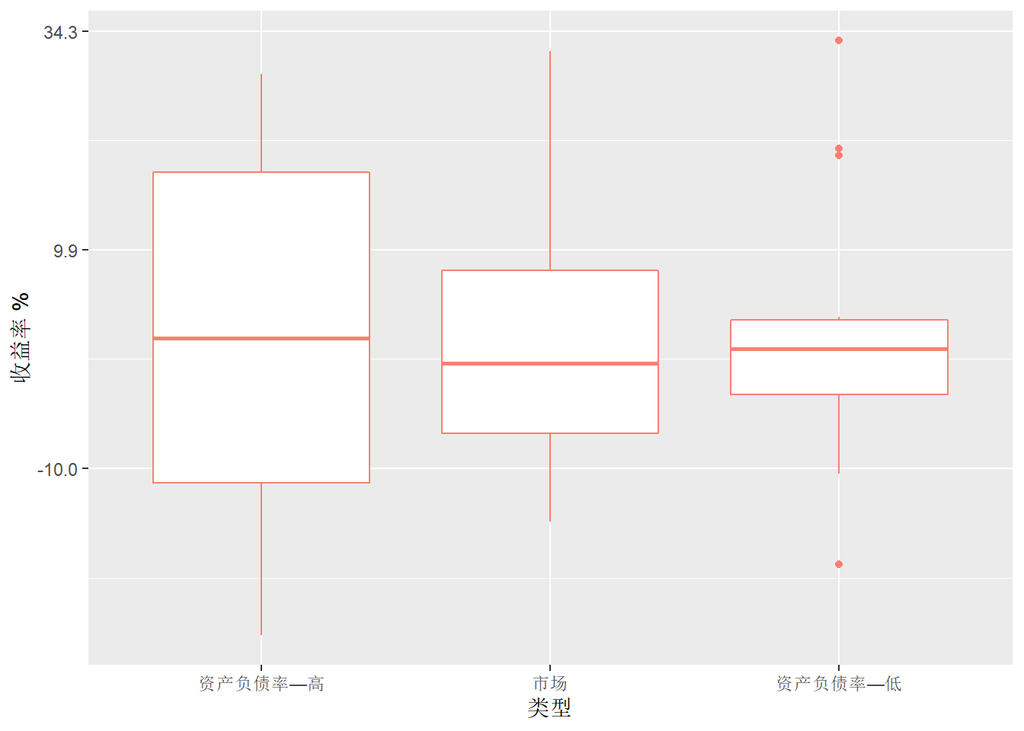

```r
#选取资产负债率排名前20的股票作为资产负债率—高的组合，以及选取资产负债率排名后20的股票作为资产负债率—低的组合
data3=df_jiben %>%
  group_by(时间) %>%
  arrange(资产负债率)%>%
  mutate(lowmeans=mean(yield[1:20]),highmeans=mean(yield[(length(yield)-19):length(yield)]),market=mean(yield))
#提取出每一季度的三类组合的收益率
data3.1=unique(data3[,11:13])

#为资产负债率三类组合的收益率分布打上类型的标签
output3=data.frame(收益率=c(data3.1$lowmeans,data3.1$market,data3.1$highmeans),类型=c(rep("资产负债率—低",14),rep("市场",14),rep("资产负债率—高",14)))
#固定箱线图的排序
output3$类型=factor(output3$类型, levels=c("资产负债率—高","市场","资产负债率—低"))
# 用ggplot函数绘制资产负债率的分组箱线图
p3=ggplot(data=output3,aes(x=类型,y=log(100+收益率)))+geom_boxplot(colour="salmon")+scale_fill_hue(c=45, l=80)+labs(y="收益率 %")+scale_y_continuous(breaks = c(4.5,4.7,4.9),labels = c("-10.0","9.9","34.3"))
p3
```

解读：可以看出选出的资产负债率高的股票组合相比市场显著波动更大，而资产负债率低的股票组合相比市场显著波动更小。这说明上季度偿债能力指标高的股票组合，相比偿债能力指标低的股票组合以及市场，在这季度的收益率大概率会波动更大。

## 任务六

构建线性回归选股策略，并绘制其收益图：建立线性回归模型，并使用step函数（设置参数trace=0）通过逐步回归法来筛选变量。模型建成后用做选股策略，并用ggplot绘制股票组合的收益情况图。

提示：  
1.在使用逐步回归来筛选变量时，需要先使用lm函数来建立线性回归模型，yield为因变量，其余变量作为自变量。  
2.在使用逐步回归来筛选变量时，需要用AIC准则来选择变量，在输出结果时可以使用summary函数。  
3.建立选股策略，按时间循环建立线性回归模型进行选股，选取预测收益率排名前五的股票作为股票组合。(将前五日股票数据回归得到的线性回归模型作为下一个五日的收益率预测模型)

```r
#提取交易日数据
time=unique(stock$时间)
#选取第一个五天的股票数据
t1=subset(stock,stock$时间==time[1])
t_data1=t1[,4:14]
#建立线性回归模型
model1<-lm(yield~.,data=t_data1)
#用AIC准则选择变量
logit.aic=step(model1,trace=0,k=2)
#使用summary函数输出筛选变量后的建模结果
summary(logit.aic)
```

```
##
## Call:
## lm(formula = yield ~ macd + kdj + rsi + wr + 每股收益 + 每股净资产 +
##     资产负债率 + 总资产周转率, data = t_data1)
##
## Residuals:
##     Min      1Q  Median      3Q     Max
## -45.011  -2.783  -0.693   2.065  57.447
##
## Coefficients:
##               Estimate Std. Error t value Pr(>|t|)
## (Intercept)   4.357497   0.303248  14.369  < 2e-16 ***
## macd          0.099425   0.048797   2.038 0.041675 *
## kdj          -0.186321   0.101344  -1.839 0.066074 .
## rsi           0.994389   0.274536   3.622 0.000296 ***
## wr            0.138069   0.057026   2.421 0.015522 *
## 每股收益      3.179384   0.323265   9.835  < 2e-16 ***
## 每股净资产   -0.111948   0.041537  -2.695 0.007069 **
## 资产负债率   -0.022373   0.004727  -4.733  2.3e-06 ***
## 总资产周转率  1.107095   0.358952   3.084 0.002057 **
## ---
## Signif. codes:  0 '***' 0.001 '**' 0.01 '*' 0.05 '.' 0.1 ' ' 1
##
## Residual standard error: 5.846 on 3470 degrees of freedom
## Multiple R-squared:  0.0571, Adjusted R-squared:  0.05493
## F-statistic: 26.27 on 8 and 3470 DF,  p-value: < 2.2e-16
```

```r
#选取下一个五天的股票数据
t2=subset(stock,stock$时间==time[2])
t_data2=t2[,4:14]
#预测收益率
pre.f<-predict(logit.aic,newdata=t_data2)
#将股票数据与预测收益率组合
tt_pre=data.frame(true=t_data2$yield,pre=pre.f)
#按照预测收益率排名进行选股
tt_pre=tt_pre[order(tt_pre$pre),]
#计算下一个五天股票组合的实际收益率
zuhe1.1=mean(tt_pre$true[1:5])
zuhe1.1
```

```
## [1] 3.08467
```

```r
#建立选股策略，循环选股
zuhe1=c()
for(i in 1:23){
  #选取第i个五天的股票数据
  t1=subset(stock,stock$时间==time[i])
  t_data1=t1[,4:14]
  #建立线性回归模型，按照AIC值选择最优模型
  model1<-lm(yield~.,data=t_data1)
  logit.aic=step(model1,trace=0)
  #选取第i+1个五天的股票数据
  t2=subset(stock,stock$时间==time[(i+1)])
  t_data2=t2[,4:14]
  #使用模型预测
  pre.f<-predict(logit.aic,newdata=t_data2)
  #组合真实收益率与预测收益率
  tt_pre=data.frame(true=t_data2$yield,pre=pre.f)
  #按照预测收益率进行排序选股
  tt_pre=tt_pre[order(tt_pre$pre,decreasing = T),]
  zuhe1=rbind(zuhe1,excess=mean(tt_pre$true[1:5])-mean(tt_pre$true))
}
summary(zuhe1)
```

```
##        V1
##  Min.   :-4.3831
##  1st Qu.:-0.6886
##  Median : 0.6228
##  Mean   : 0.5223
##  3rd Qu.: 1.4529
##  Max.   : 5.7042
```

```r
#计算累计超额收益率
cum_yield1=cumprod(1+zuhe1/100)[23]
cum_yield1-1
```

```
## [1] 0.1210449
```

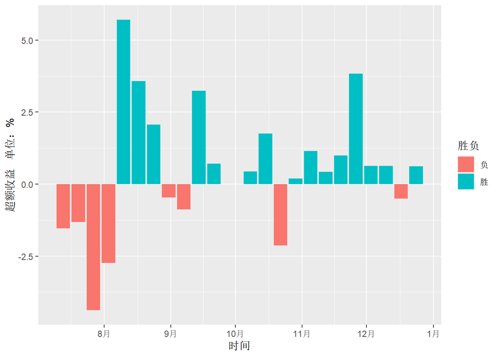

```r
#按照股票组合的超额收益率打上“胜”、“负”的标签
sf=c()
#超额收益率大于0的打上“胜”的标签
n1=which(zuhe1>0)
sf[n1]=rep("胜",length(n1))
#超额收益率小于等于0的打上“负”的标签
n2=which(zuhe1<=0)
sf[n2]=rep("负",length(n2))
#组合数据
data1=data.frame(时间=time[2:24],超额收益=zuhe1,胜负=sf)
data1$时间=as.Date(data1$时间)
#用ggplot函数绘制股票组合胜负的柱状图
p3=ggplot(data=data1,aes(x=时间,y=超额收益,fill=胜负))+geom_bar(stat="identity")+labs(x="时间",y="超额收益   单位：%")
p3
```

解读：可以看到基本+技术的线性回归模型的胜率高且超额收益相对稳定,其最高超额收益率达到5.7%，最低为-4.4%，且其累计超额收益率达到12.1%。这说明基本+技术的线性回归模型在A股市场表现良好。

## 任务七

构建随机森林选股策略，并绘制其收益图：使用randomForest函数建立随机森林模型，通过varImpPlot函数来展示模型中各个变量的重要性，并用ggplot绘制股票组合的收益情况图。

提示：  
1.建立选股策略，按时间循环建立随机森林模型进行选股，选取预测收益率达到最大预测值80%以上的股票作为股票组合。(将前一个五天股票数据回归得到的随机森林模型作为下一个五天的收益率预测模型)

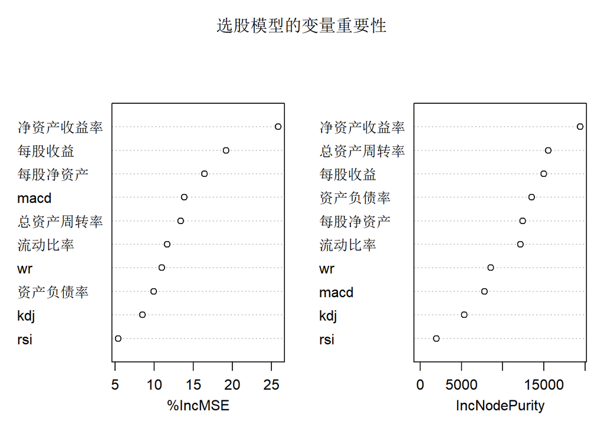

```r
#选取第一个五天的股票数据
t1=subset(stock,stock$时间==time[1])
t_data1=t1[,4:14]
#建立随机森林模型
fit.f<- randomForest(yield~., data =t_data1,
                       na.action = na.roughfix,
                       importance = TRUE)
#使用varImpPlot函数来展示模型中各个变量的重要性
varImpPlot(fit.f, main = "选股模型的变量重要性")
```

```r
#选取下一个五天的股票数据
t2=subset(stock,stock$时间==time[2])
t_data2=t2[,4:14]
#预测收益率
pre.f<-predict(fit.f,newdata=t_data2)
#将股票数据与预测收益率组合
tt_pre=data.frame(true=t_data2$yield,pre=pre.f)
#按照预测收益率大小进行选股
tt=tt_pre[which(tt_pre$pre>max(tt_pre$pre)-0.2*abs(max(tt_pre$pre))),]
#计算下一个五天股票组合的实际收益率
zuhe2.1=mean(tt$true)
zuhe2.1
```

```
## [1] 0.6476412
```

```r
#建立选股策略，循环选股
set.seed(123)
zuhe2=c()
for(i in 1:23){
  #选取第i个五天的股票数据
  t1=subset(stock,stock$时间==time[i])
  t_data1=t1[,4:14]
 #建立随机森林模型
  fit.f<- randomForest(yield~., data =t_data1,
                       na.action = na.roughfix,
                       importance = TRUE)
  #选取第i+1个五天的股票数据
  t2=subset(stock,stock$时间==time[(i+1)])
  t_data2=t2[,4:14]
  #预测收益率
  pre.f<-predict(fit.f,newdata=t_data2)
  #将股票数据与预测收益率组合
  tt_pre=data.frame(true=t_data2$yield,pre=pre.f)
  #按照预测收益率大小进行选股
  tt=tt_pre[which(tt_pre$pre>max(tt_pre$pre)-0.2*abs(max(tt_pre$pre))),]
  zuhe2=rbind(zuhe2,excess=mean(tt$true)-mean(tt_pre$true))
}
#查看股票组合的超额收益率状况
summary(zuhe2)
```

```
##        V1
##  Min.   :-14.9272
##  1st Qu.: -4.9261
##  Median : -0.4501
##  Mean   :  3.9467
##  3rd Qu.:  3.9022
##  Max.   : 59.0642
```

```r
#计算累计收益率
cum_yield2=cumprod(1+zuhe2/100)[23]
cum_yield2-1
```

```
## [1] 0.8549179
```

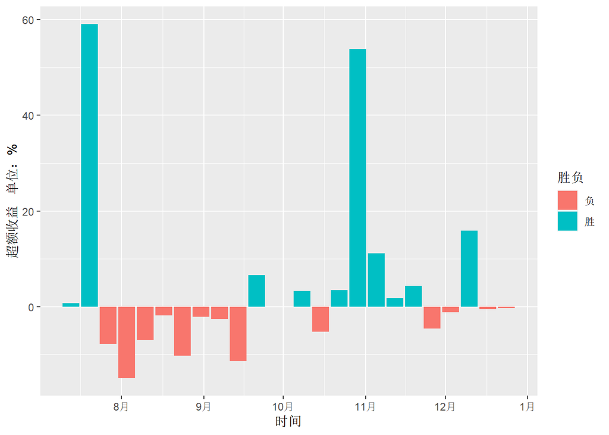

```r
#按照股票组合的超额收益率打上“胜”、“负”的标签
sf=c()
#超额收益率大于0的打上“胜”的标签
n1=which(zuhe2>0)
sf[n1]=rep("胜",length(n1))
#超额收益率小于等于0的打上“负”的标签
n2=which(zuhe2<=0)
sf[n2]=rep("负",length(n2))
#组合数据
data2=data.frame(时间=time[2:24],超额收益=zuhe2,胜负=sf)
data2$时间=as.Date(data2$时间)
#用ggplot函数绘制股票组合胜负的柱状图
p4=ggplot(data=data2,aes(x=时间,y=超额收益,fill=胜负))+geom_bar(stat="identity")+labs(x="时间",y="超额收益   单位：%")
p4
```

## 任务八

使用ggplot函数绘制两种选股模型的收益率比较图：绘制分组箱线图。 提示： 1.当箱线图由于“异常值”过于扁平时，可将其去除后再画一个图，在分析时再结合“异常值”进行讨论。

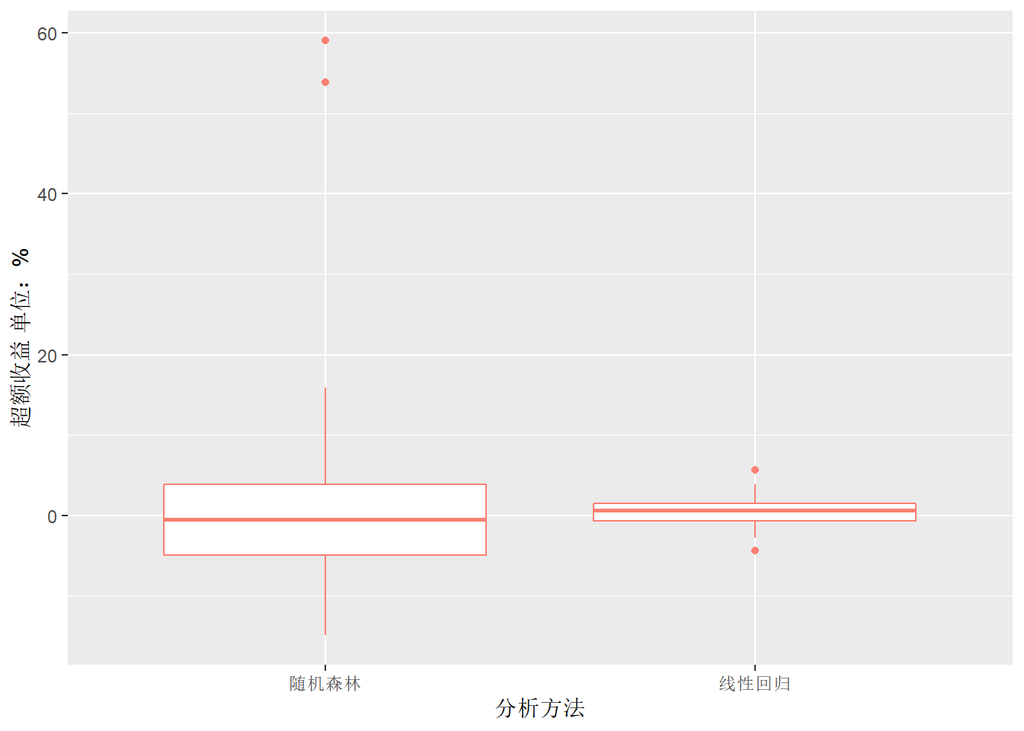

```r
#给不同选股模型的股票组合打上标签
comparison=data.frame(超额收益=c(zuhe1,zuhe2),分析方法=c(rep("线性回归",23),rep("随机森林",23)))
#使用ggplot绘制超额收益率比较图
pp1=ggplot(comparison,aes(x=分析方法,y=超额收益))+geom_boxplot(col="salmon")+labs(x="分析方法",y="超额收益 单位：%")
pp1
```

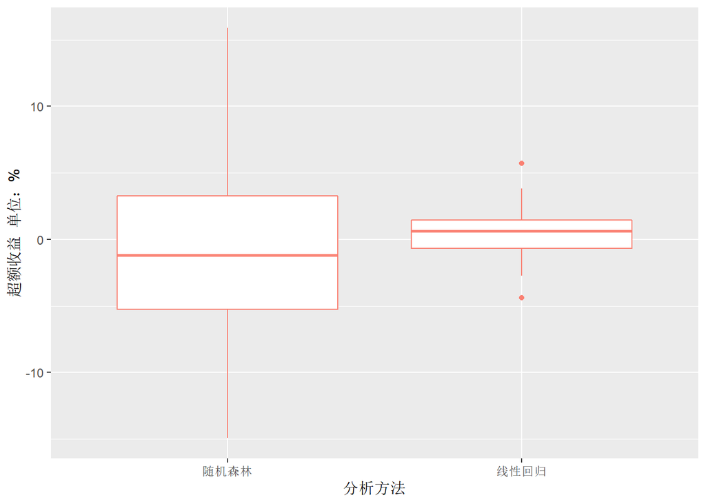

```r
#去除“异常值”之后进行对比
comparison=comparison[which(comparison$超额收益<20),]
#再次绘制超额收益率比较图
pp2=ggplot(comparison,aes(x=分析方法,y=超额收益))+geom_boxplot(col="salmon")+labs(x="分析方法",y="超额收益  单位：%")
pp2
```

解读：可以看到去除随机森林的几次超高收益的情况后，随机森林模型的整体表现比线性回归模型更差。不仅中位数更低，并且波动更大。对于风险偏好低、收益期望一般的投资者，更适用于基本+技术的线性回归模型，其胜率高且超额收益稳定；而对于风险偏好高、收益期望高的投资者，明显更适用于基本+技术的随机森林模型，其胜率低但超额收益上界高。